# Price Prediction - Airbnb Apartments in Milan

Can we predict the price of an Airbnb apartment in Milan?

by Peter Hontaru

[figure not shown]

Airbnb logo

```r
knitr::opts_chunk$set(
    echo = TRUE, # show all code
    tidy = FALSE, # cleaner code printing
    size = "small", # smaller code

    fig.path = "figures/",# where the figures will end up
    out.width = "100%",

    message = FALSE,
    warning = FALSE
    )
```

# 1 Introduction

## 1.1 Problem statement

**Can we predict the price at which an apartment should be rented based on a number of variables? If so, which variables influenced the price the most?**

## 1.2 Who is this project intended for?

- **landlords** looking to calculate the optimal price for their apartment
- **tourists** trying understand if they’re getting a good deal
- *those looking to find a model that might fit other datasets, since the Airbnb data is generally standardised across countries/cities*

## 1.3 Why this dataset?

I’ve always been fascinated by the italian culture, history, places and food, so much so that this year I’ve started learning Italian. While looking to work on a data science project, I found this dataset on kaggle and thought it would be interesting to dive into it.

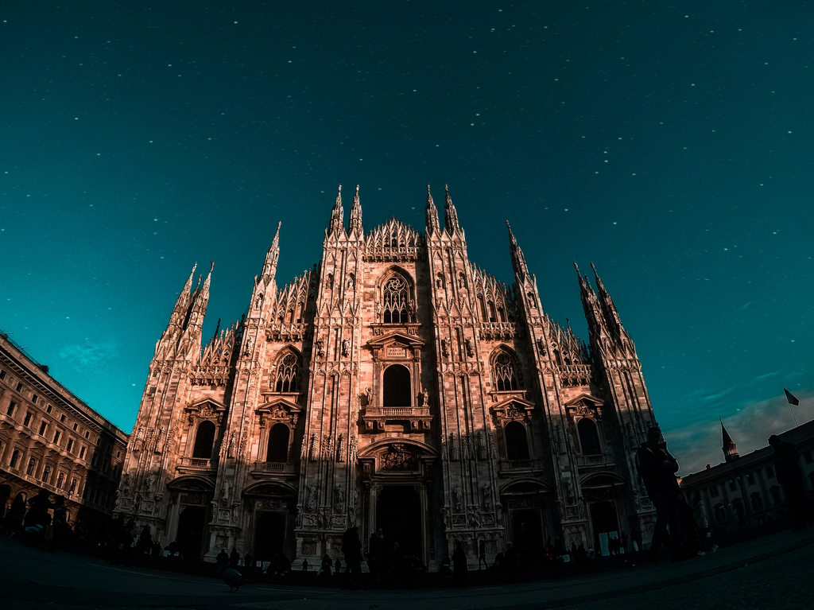

Thanks to Benjamin Voros for this picture of the Milan Cathedral (Duomo di Milano).

## 1.4 Summary:

- we used three different models in our project:
  - **Stepwise Regression**(Rsquared 0.432)
  - **Gradient Boosting Machine**(0.446)
  - **Random Forrest**(0.486)
- the **Random Forrest** model was proven to be the most optimal model:
  - **Rsquared**(0.486)
  - **MAE** ($29)
  - **RMSE** ($42)
- while this model has a similar or higher Rsquared to that of other Airbnb analyses (ie. Milan, New York), **it is not high enough to provide an accurate predicton**, shown by an average error of ~$29, **but precise enough to provide a range**
- the most important variables were shown to be the number of **bedrooms**, **bathrooms**, **reviews**, and **number of people to accommodate**
- the **region** did not prove to be a significant predictor of the price. Rather, the proximity to the city centre was shown to be more important, as shown by the **latitude**, **longitude** or **zipcode group**
- the usual **services** we look for when booking accommodation (Wi-Fi, heating, kitchen, etc) were not shown to be important in predicting prices, given that most apartments have them and thus, they weren’t enough to justify a higher price

**NB**: A logarithmic approach to the price prediction model was also used outside of this analyis. However, I decided against including that in this wrap-up due to the following:

- it did not produce significantly better results
- it would make the wrap-up a lot longer (almost 2x the length of the current version)
- its stats are not as straightforward to understand

## 1.5 Next steps / Recommendations:

- there are a number of variables which are not included in this dataset such as apartment size, picture analysis, text of the reviews and the description of the property which would have improved the accuracy of the model. Assessing these would likely improve the performance of the prediction model
- it might also prove helpful to develop a dashboard where the user can input variables and receive a prediction range that they might want to consider

## 1.6 Where did the data come from?

The dataset was downloaded from kaggle (link below). It was made available by Antonio Mastrandrea and it is representative of the Airbnb data in July 2019.

https://www.kaggle.com/antoniokaggle/milan-airbnb-open-data-only-entire-apartments

# 2 Data import, tidying, cleaning

Clean up data and add some new features:

```r
setwd("~/DS/AHT/Data")

#import data
raw_data <- read_csv("~/DS/AirBnb-Milano-Price-Prediction/raw data/Airbnb_Milan.csv")

#tidy up data
raw_data <- raw_data %>%
        select(-X1, -room_type)%>%
        mutate(Region = as.factor(neighbourhood_cleansed),
               #new features
               total_price = daily_price + cleaning_fee,
               cleaning_fee_perc = round(cleaning_fee/total_price,2)*100,
               security_deposit_perc = round(security_deposit/total_price,2)*100,
               availability_30_perc = round(availability_30/30,2)*100,
               availability_60_perc = round(availability_60/60,2)*100,
               availability_90_perc = round(availability_90/90,2)*100,
               availability_365_perc = round(availability_365/365,2)*100)
```

Check the *structure* of the dataset:

```r
#check structure
glimpse(raw_data)
```

```
## Rows: 9,322
## Columns: 67
## $ id                               <dbl> 73892, 74169, 77958, 93025, 132705...
## $ host_id                          <dbl> 387110, 268127, 387110, 499743, 39...
## $ host_location                    <dbl> 1, 1, 1, 1, 1, 1, 1, 1, 1, 1, 1, 1...
## $ host_response_time               <dbl> 1, 1, 1, 1, 1, 0, 1, 1, 1, 1, 1, 1...
## $ host_response_rate               <dbl> 57, 57, 57, 57, 57, 29, 57, 57, 57...
## $ host_is_superhost                <dbl> 0, 0, 0, 0, 1, 0, 1, 0, 0, 0, 0, 0...
## $ host_total_listings_count        <dbl> 3, 1, 3, 1, 2, 8, 6, 2, 8, 22, 22,...
## $ host_has_profile_pic             <dbl> 1, 1, 1, 1, 1, 1, 1, 1, 1, 1, 1, 1...
## $ host_identity_verified           <dbl> 1, 0, 1, 0, 0, 1, 0, 0, 1, 0, 0, 0...
## $ neighbourhood_cleansed           <dbl> 1, 1, 1, 1, 1, 1, 1, 1, 1, 1, 1, 1...
## $ zipcode                          <dbl> 20121, 20121, 20121, 20121, 20135,...
## $ latitude                         <dbl> 45.47015, 45.47169, 45.47117, 45.4...
## $ longitude                        <dbl> 9.19134, 9.18412, 9.19135, 9.19640...
```

[output cut: 54 more lines]

Check for *Null*s:

```r
#check for nulls
raw_data %>% summarise_all(~ sum(is.null(.))) %>% sum()
```

```
## [1] 0
```

Check for *NA*s:

```r
#check NAs
raw_data %>% summarise_all(~ sum(is.na(.))) %>% sum()
```

```
## [1] 0
```

Now that we’ve tidied up the table and added some new features, we can start by exploring our data.

# 3 Exploratory Data Analysis (EDA)

## 3.1 Correlation plot

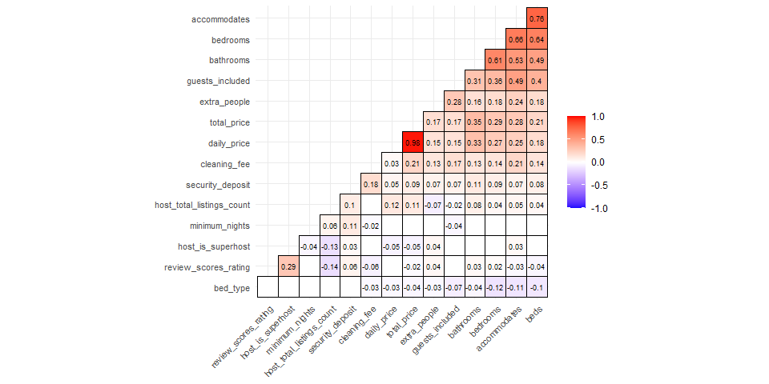

```r
#select all to start
#raw_data_corr <- select_if(raw_data, is.numeric)

#only a few specific ones
raw_data_corr <- raw_data%>%
        select(accommodates, bathrooms, bedrooms, beds, bed_type, daily_price, total_price, security_deposit,
               cleaning_fee, review_scores_rating, guests_included,
               extra_people, minimum_nights, host_total_listings_count, host_is_superhost)

# Compute a correlation matrix
corr <- round(cor(raw_data_corr),2)

# Compute a matrix of correlation p-values
p.mat <- cor_pmat(raw_data_corr)

# Visualize the correlation matrix
ggcorrplot(corr, method = "square",
           ggtheme = ggplot2::theme_minimal,
           #title = "We can observe some clear patterns",

           outline.col = "black",
           colors = c("blue","white", "red"),

           lab = TRUE,
           lab_size = 2.5,
           digits = 2,

           type = "lower",
           legend = "",
           tl.cex = 8,
           #show insignificant ones as blank
           p.mat = p.mat,
           hc.order = TRUE,
           insig = "blank")
```

**Key findings**:

- unsurprisingly, **the total price correlated with the number of bedrooms, bathrooms and the number of people it accommodates**
- to note that there was a **higher correlation with the number of bathrooms than the bedrooms**. This could be due to the fact that some apartments have an artificially higher number of bedrooms, but not bathrooms
- there is a **positive correlation between the superhost status and the rating**. This might mean that superhosts are more likely to be experienced landlords and provide a better customer experience

## 3.2 What does the price distribution look like across all regions?

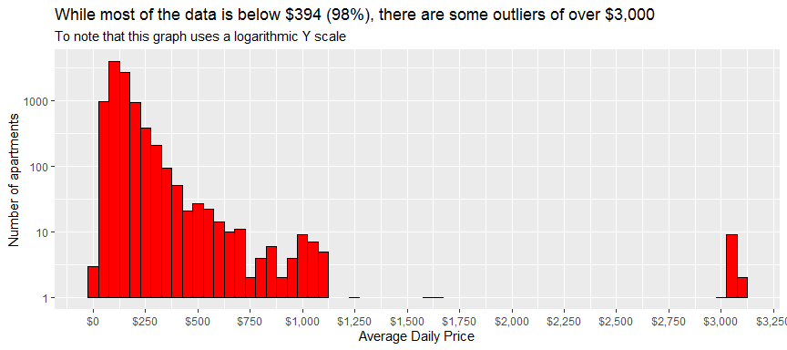

```r
ggplot(raw_data, aes(total_price))+
  geom_histogram(binwidth = 50,col = "black", fill = "red")+
  scale_y_log10()+
  scale_x_continuous(labels = dollar_format(), n.breaks = 15)+
  labs(x="Average Daily Price",
       y= "Number of apartments",
       title = "While most of the data is below $394 (98%), there are some outliers of over $3,000",
       subtitle = "To note that this graph uses a logarithmic Y scale")
```

## 3.3 What does the distribution of the apartments look like?

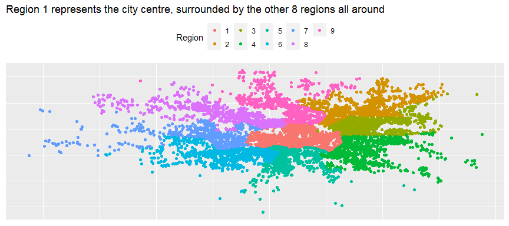

```r
ggplot(raw_data, aes(longitude, latitude, col=Region)) +
        geom_point()+
        labs(x=NULL,
             y=NULL,
             title="Region 1 represents the city centre, surrounded by the other 8 regions all around")+
        theme(axis.ticks.y = element_blank(),axis.text.y = element_blank(),
              axis.ticks.x = element_blank(),axis.text.x = element_blank(),
              #plot.title = element_text(lineheight=.8, face="bold", vjust=1),
              legend.position = "top")
```

## 3.4 How does the price differ between regions?

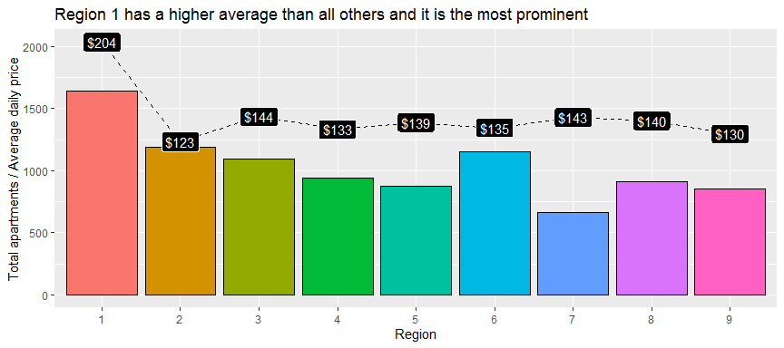

```r
data_by_region <- raw_data%>%
        group_by(Region)%>%
        summarize(count = n(),
                  avg_price = mean(total_price),
                  med_price = median(total_price))

ggplot(data_by_region, aes(Region, count, fill = Region))+
        geom_col(col = "black")+
        geom_line(aes(Region, avg_price*10), group = 1, lty = 2)+
        geom_label(aes(Region, avg_price*10, label = paste("$", round(avg_price), sep = "")), fill = "black", col = "white")+
        labs(y = "Total apartments / Average daily price",
             x = "Region",
             title = "Region 1 has a higher average than all others and it is the most prominent")+
        theme(legend.position = "none")
```

## 3.5 What is the price variability of each region?

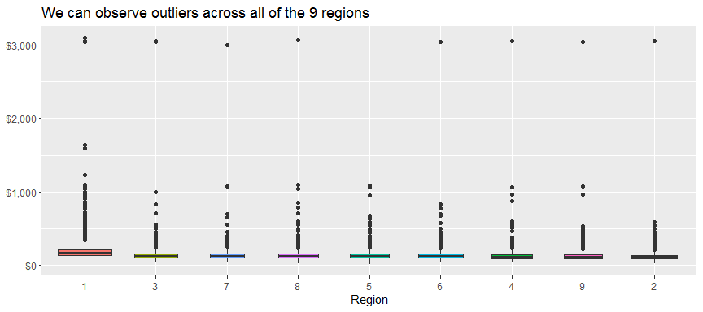

```r
ggplot(raw_data, aes(reorder(Region, desc(total_price)), total_price, fill = Region))+
        geom_boxplot(varwidth = TRUE)+
        scale_y_continuous(labels = dollar_format())+
        labs(y = NULL,
             x = "Region",
             title = "We can observe outliers across all of the 9 regions")+
        theme(legend.position = "none")
```

Let’s break down our price range into percentiles in order to better understand its distribution:

```r
percentiles <- quantile(raw_data$total_price, c(0.50, 0.75, 0.80, 0.90, 0.95, 0.96, 0.97, 0.98, 0.99, 0.999, 1))

percentiles %>%
  kbl(caption = c("Custom percentile table"),
      col.names = "Average Daily Price",
      align = c("c", "c")) %>%
  kable_paper("hover", full_width = F)
```

Custom percentile table

|  | Average Daily Price |
| --- | --- |
| 50% | 124.00 |
| 75% | 160.00 |
| 80% | 174.00 |
| 90% | 221.00 |
| 95% | 284.00 |
| 96% | 304.00 |
| 97% | 335.00 |
| 98% | 394.58 |
| 99% | 567.74 |
| 99.9% | 3045.00 |
| 100% | 3100.00 |

## 3.6 What does the price variability of each region look like if we exclude the outliers?

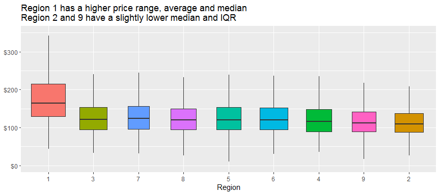

```r
ggplot(raw_data, aes(reorder(Region, desc(total_price)), total_price, fill = Region))+
        geom_boxplot(outlier.shape = NA, varwidth = TRUE)+
        coord_cartesian(ylim=c(0,350))+
        scale_y_continuous(labels = dollar_format())+
        labs(y = NULL,
             x = "Region",
             title = "Region 1 has a higher price range, average and median \nRegion 2 and 9 have a slightly lower median and IQR")+
        theme(legend.position = "none")
```